# Homework

The file `lynx.gen` in the data folder contains microsatellite data for eight Eurasian lynx populations.

Here’s a pretty pic, so we know what we’re working on.

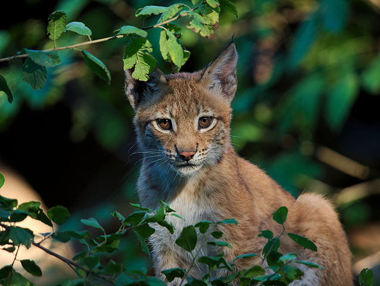

Eurasian lynx, from wikimedia.org

This large felid used to occur throughout Europe, but was virtually extinct in central and western Europe by the 19th century.

In an effort to re-establish the species, lynx were re-introduced in some EU countries in the last decades.

You can see their distribution here on the IUCN webpage: https://www.iucnredlist.org/species/12519/121707666

Re-introductions frequently involve only a small number of animals. Especially, if they are dangerous!

Having a small *founding population* can impact genetic diversity:

- first of all, you are only introducing variation present in a few individuals
- second, not all introduced animals will mate (so variation will be lost)
- third, population size impacts the maintenance of variation. Small populations often lose variation due to genetic drift.

`lynx.gen` includes data for lynx from natural populations as well as re-introduced populations.

Not all of the re-introductions were documented. We can use genetics to try and figure out where re-introduced lynx originated.

# Tasks

Your mission, should you chose to accept it, is to run your `R` based analyses on this new data, and generate a report (= results + your interpretation).

Clearly mark your interpretation using *Markdown* code. E.g. you can use **MY NAME: ….**.

**Population names**

The eight populations come from:

- Estonia
- Latvia
- Poland
- Russia
- Slovenia
- Croatia
- France
- Slovakia

They are in this order in the file.

**Note:** You will need to rename the populations in your `myData` accordingly.

You can check that you have named them correctly, because the sample ID gives a clue as to where the samples are from.

Be careful to not automatically remove loci/pops/individuals, as you did previously with the data from `nancy.gen`. Only remove them if warranted.

### **Natural vs re-introduced populations**

Lynx from Estonia, Latvia, Poland, Russia and Slovakia are from natural populations.

Lynx from Slovenia, Croatia and France come from re-introduced populations.

**QUESTION: How do these types of populations differ?**

### **Subspecies**

Eurasian lynx in Europe belong to two subspecies: Lynx lynx lynx, and L. l. carpathicus.

*L. l. lynx:*

- Estonia
- Latvia
- Poland
- Russia

*L. l. carpathicus:*

- Slovenia
- Croatia
- Slovakia

**QUESTION: Can you tell to which subspecies does the French lynx belong?**